# Reproducible Research Assignment 1

## Loading and preprocessing the data

##### The data should be present in your wroking directory and already unzipped. The data will be loaded in variable called data. We will process the data as we go along.

```r
data<-read.csv("activity.csv")
```

## What is mean total number of steps taken per day?

##### For this part of the assignment the missing values can be ignored

- Calculate the total number of steps taken per day.
- Make a histogram of the total number of steps taken each day.
- Calculate and report the mean and median of the total number of steps taken per day.

##### For the frist part we could simply apply tapply function to find out steps taken each day. In order to understand the distribution - a simple histogram will idicate how steps taken per day varies

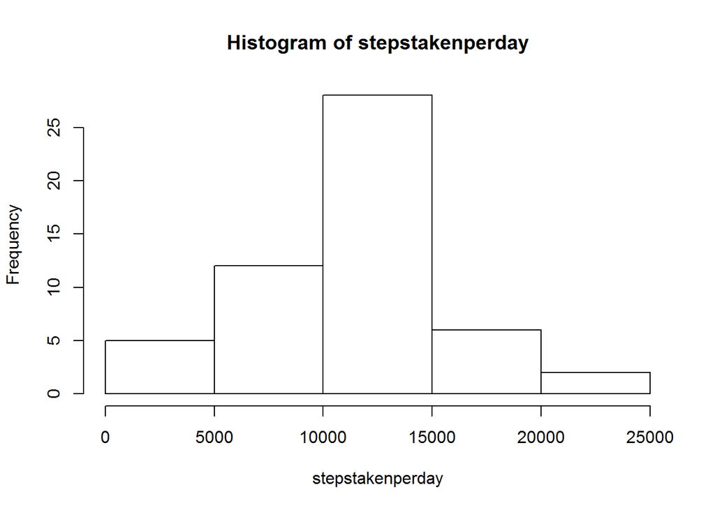

```r
stepstakenperday<-tapply(data$steps, data$date, sum)
hist(stepstakenperday)
```

Where as the mean and median of the steps taken are:

```r
mean<-mean(stepstakenperday, na.rm=TRUE)
median<-median(stepstakenperday,na.rm=TRUE)
mean
```

```
## [1] 10766.19
```

```r
median
```

```
## [1] 10765
```

## What is the average daily activity pattern?

Once again I will use tapply to find out avg no of steps during an interval - while ignoring the NA values.

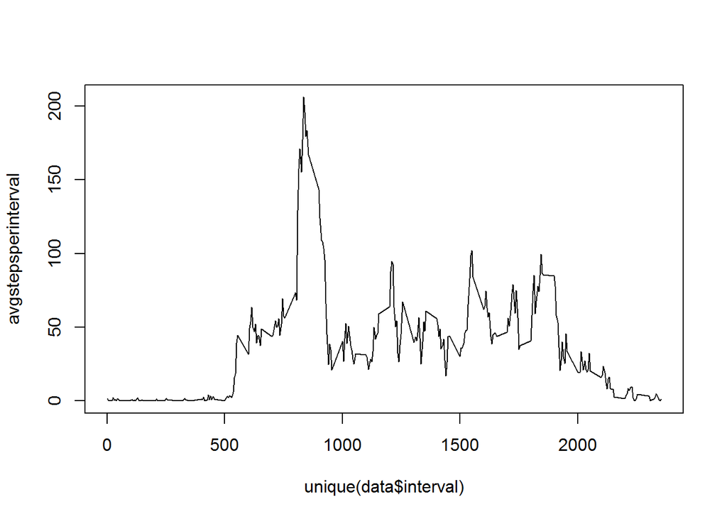

```r
avgstepsperinterval<-tapply(data$steps, data$interval, mean,na.rm=TRUE)
plot(unique(data$interval),avgstepsperinterval, type = "l")
```

The 5-minute interval contains the maximum number of steps can be deduced by using which.max function

```r
which.max(avgstepsperinterval)
```

```
## 835
## 104
```

That is 835 interval which has an idex of 104

## Missing Values

Total number of missing values are:

```r
sum(is.na(data))
```

```
## [1] 2304
```

```r
stepsinterval<-data.frame(tapply(data$steps, data$interval, mean,na.rm=TRUE))
stepsinterval[,2]<-dimnames(stepsinterval)
names(stepsinterval)<-c("Mean","interval")
df2<-data.frame(data[is.na(data$steps),])
new<-merge(stepsinterval,df2,by.x = "interval", by.y = "interval")
data2<-data
data2[is.na(data2)]<-new[,2]
head(data2)
```

```
##      steps       date interval
## 1 1.716981 2012-10-01        0
## 2 1.716981 2012-10-01        5
## 3 1.716981 2012-10-01       10
## 4 1.716981 2012-10-01       15
## 5 1.716981 2012-10-01       20
## 6 1.716981 2012-10-01       25
```

Histogram of the total number of steps taken each day

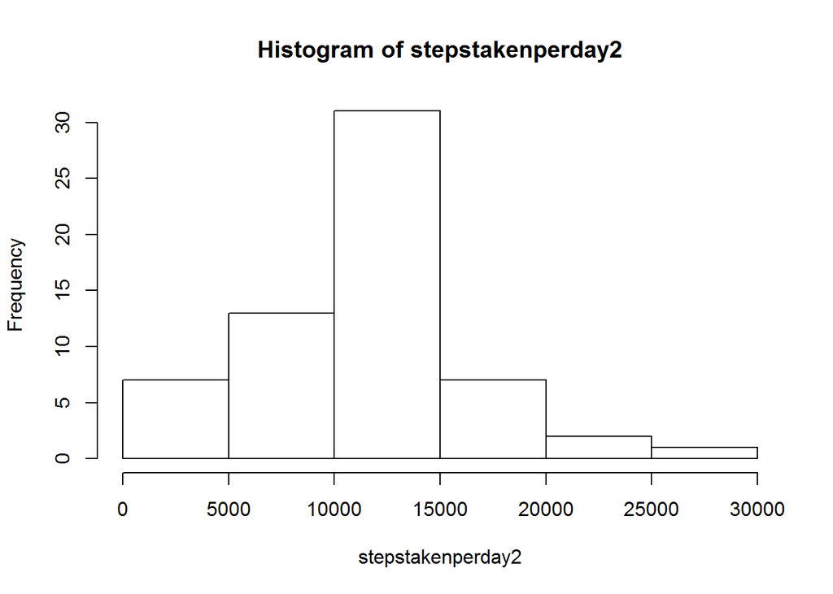

```r
stepstakenperday2<-tapply(data2$steps, data2$date, sum)
hist(stepstakenperday2)
```

Where as the mean and median of the steps taken in the new data are:

```r
mean<-mean(stepstakenperday2, na.rm=TRUE)
median<-median(stepstakenperday2,na.rm=TRUE)
mean
```

```
## [1] 10766.19
```

```r
median
```

```
## [1] 10631.7
```

Data has slightly changed but not significantly.

## Are there differences in activity patterns between weekdays and weekends?

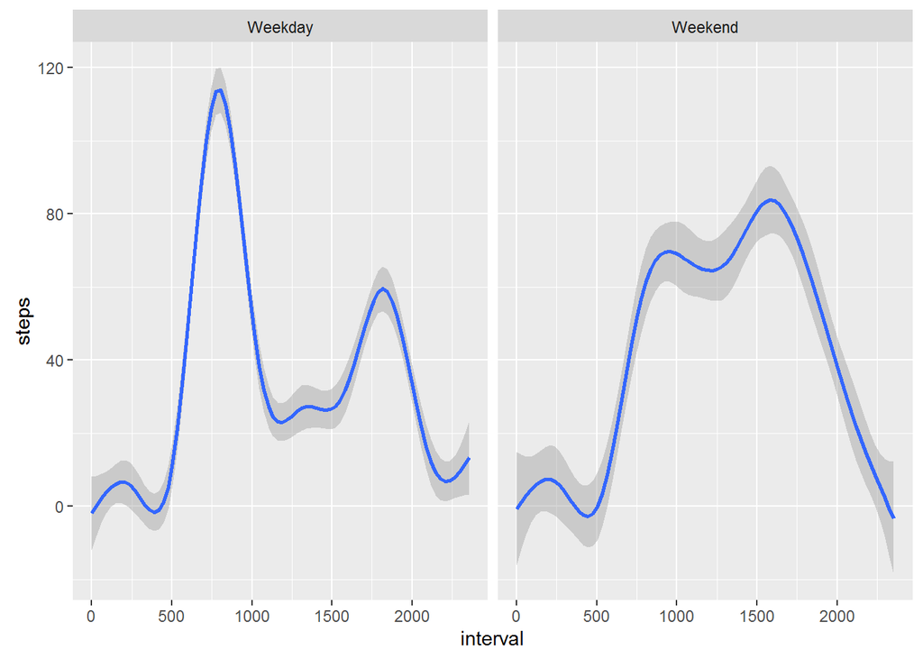

```r
data2$date<-as.Date(data2$date)
data2$weekday<-weekdays(data2$date)
df3<-data.frame(c("Saturday","Sunday","Monday","Tuesday","Wednesday","Thursday","Firday"),c("Weekend","Weekend","Weekday","Weekday","Weekday","Weekday","Weekday"))
names(df3)<-c("weekday","weekdayweekend")
last<-merge(data2,df3,by.x = "weekday", by.y = "weekday")
library(ggplot2)
qplot(interval,steps,data = last, facets = .~weekdayweekend, geom = "smooth")
```

From the above graph indiactes that activities are different on weekdays and weekend. Where on weekdays we witness hikes but on weeknds there is more uniformity.